# Plotting and Visualization in R

PS239T

18 March, 2020

> “Visualizing your data should be the beginning and end of every project.”

> “Think–what is the story you’re trying to tell? This picture **should** be worth a thousand words.”

# Plotting in R

There are two major sets of tools for creating plots in R:

- 1. base, which come with all R installations. These are mostly a quick and dirty tool–they’re often hard to read and hard to modify, but can be useful if you need to whip up a quick histogram or something similar.
- 2. ggplot2, a stand-alone package. This is going to be our primary tool for examining our data visually. It’s very powerful and makes for beautiful visualizations, but the number of options makes for a steeper learning curve at first.

Note that other plotting facilities do exist (notably **lattice**), but base and ggplot2 are by far the most popular.

## 0) SET UP

### 0.1. Setup environment

```r
# remove all objects
rm(list=ls())

# check working directory
getwd()
```

```
## [1] "C:/Users/Julia/OneDrive/Documents/Berkeley/2020-01_Spring/PS239T_Spring2020/09_r-analysis-visualization/01_analysis"
```

```r
# Change default plot dimensions
knitr::opts_chunk$set(fig.width=10, fig.height=6)
```

### 0.2. The dataset

For the following examples, we will using the gapminder dataset we saw last week. Gapminder is a country-year dataset with information on life expectancy, among other things.

```r
dat <- read.csv("../02_data/data-raw/gapminder-FiveYearData.csv")
```

## 1) R BASE GRAPHICS

- *Minimal* call takes the following form

```r
plot(x=)
```

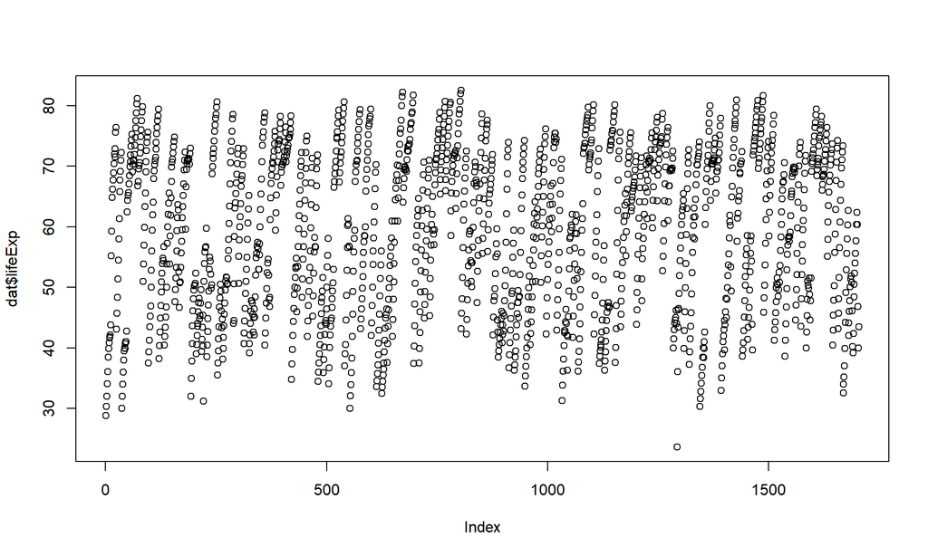

```r
# Note that when asked to plot a single vector, R will assume the index positions of each vector element are the implied horizontal dimension
plot(x = dat$lifeExp)
```

- *Basic* call takes the following form

```r
plot(x=, y=)
```

```r
plot(x = dat$gdpPercap, y = dat$lifeExp)
```

[output not shown]

### 1a. Scatter and Line Plots

- The “type” argument accepts the following character indicators
- “p” – point/scatter plots (default plotting behavior)

```r
plot(x = dat$gdpPercap, y = dat$lifeExp, type="p")
```

[output not shown]

- “l” – line graphs

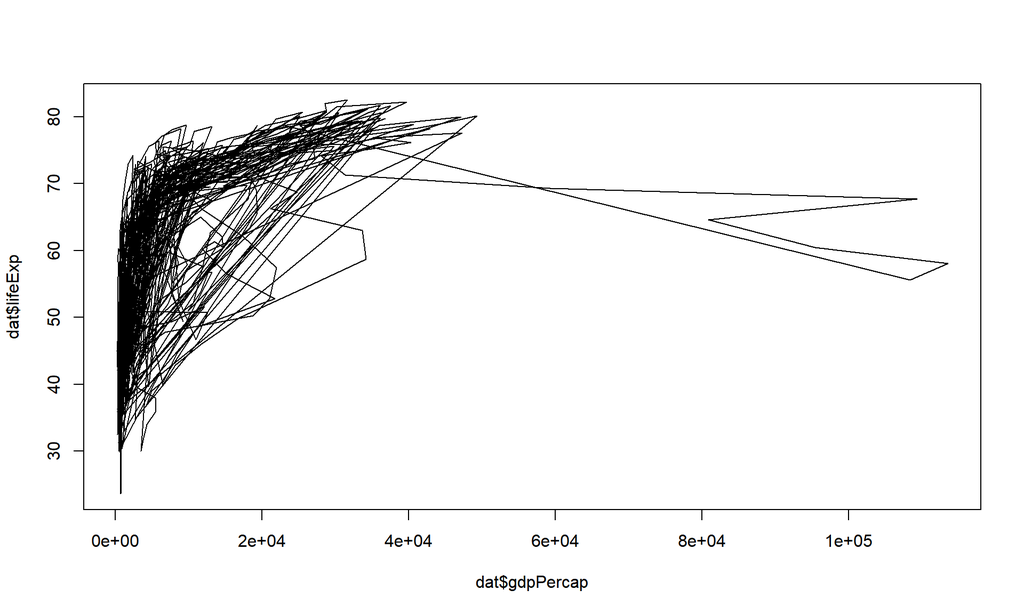

```r
# Note that "line" does not create a smoothing line, just connected points
plot(x = dat$gdpPercap, y = dat$lifeExp, type="l")
```

- “b” – both line and point plots

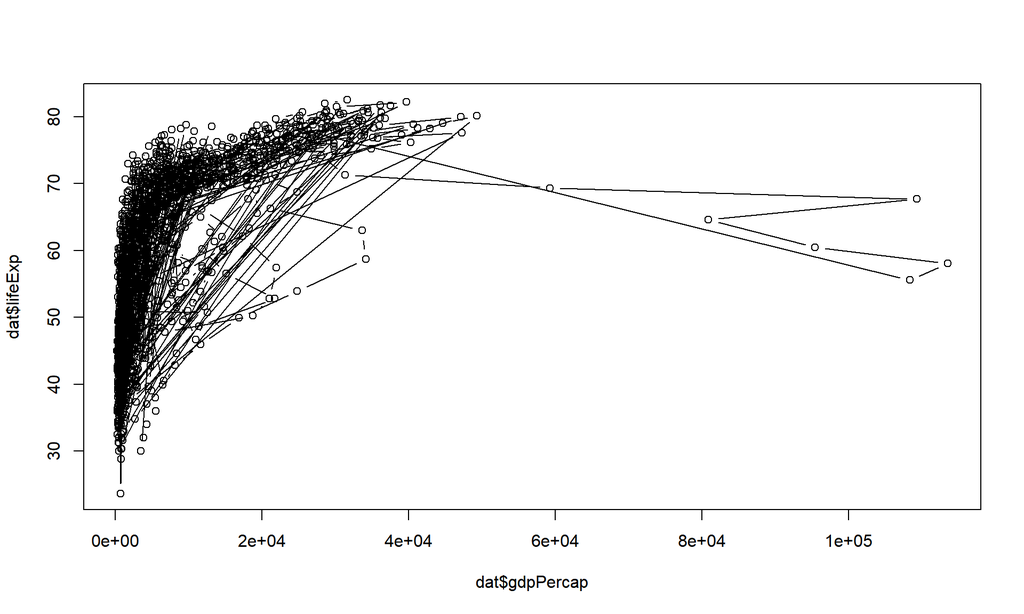

```r
plot(x = dat$gdpPercap, y = dat$lifeExp, type="b")
```

### 1b. Histograms and Density Plots

- Certain plot types require different calls outside of the “type” argument
- Ex) Histograms

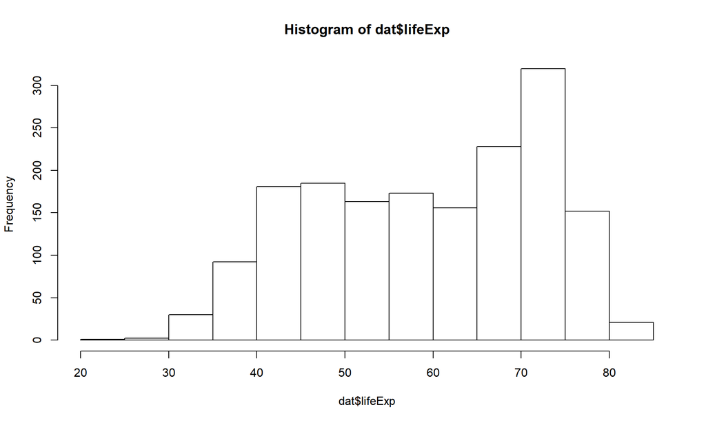

```r
hist(x=dat$lifeExp)
```

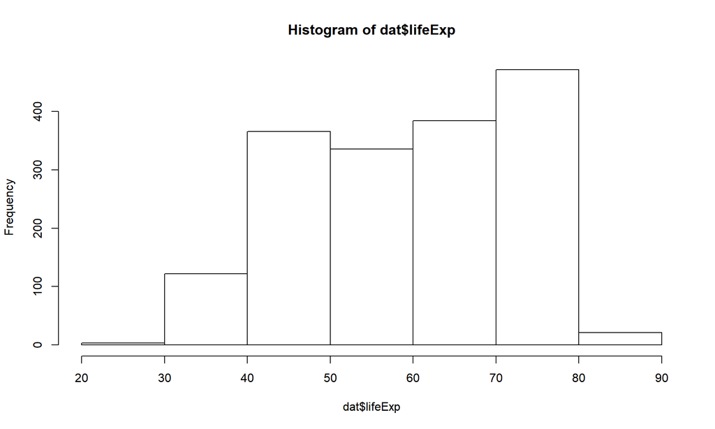

```r
hist(x=dat$lifeExp, breaks=5)
```

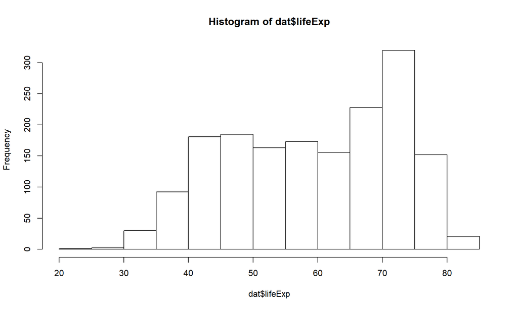

```r
hist(x=dat$lifeExp, breaks=10)
```

- Ex) Density plots

```r
# Create a density object (NOTE: be sure to remove missing values)
age.density<-density(x=dat$lifeExp, na.rm=T)
# Check the class of the object
class(age.density)
```

```
## [1] "density"
```

```r
# View the contents of the object
age.density
```

```
##
## Call:
##  density.default(x = dat$lifeExp, na.rm = T)
##
## Data: dat$lifeExp (1704 obs.);   Bandwidth 'bw' = 2.625
##
##        x               y
##  Min.   :15.72   Min.   :0.000001
##  1st Qu.:34.41   1st Qu.:0.001079
##  Median :53.10   Median :0.017034
##  Mean   :53.10   Mean   :0.013364
##  3rd Qu.:71.79   3rd Qu.:0.020987
##  Max.   :90.48   Max.   :0.034870
```

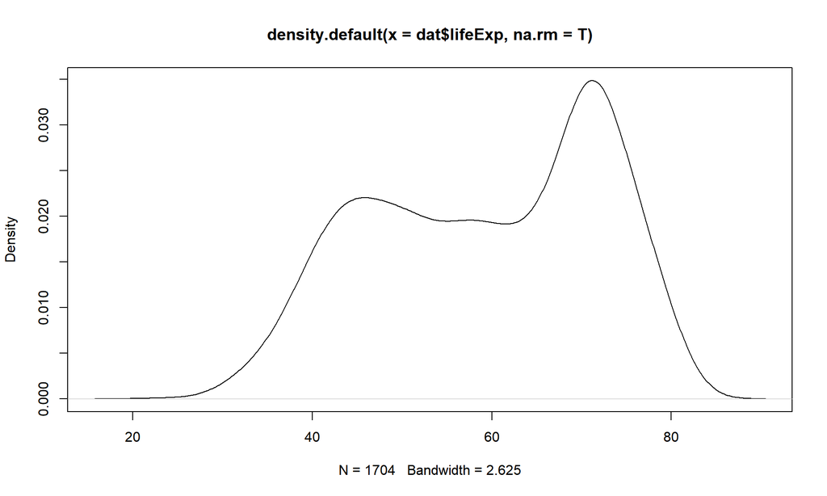

```r
# Plot the density object
plot(x=age.density)
```

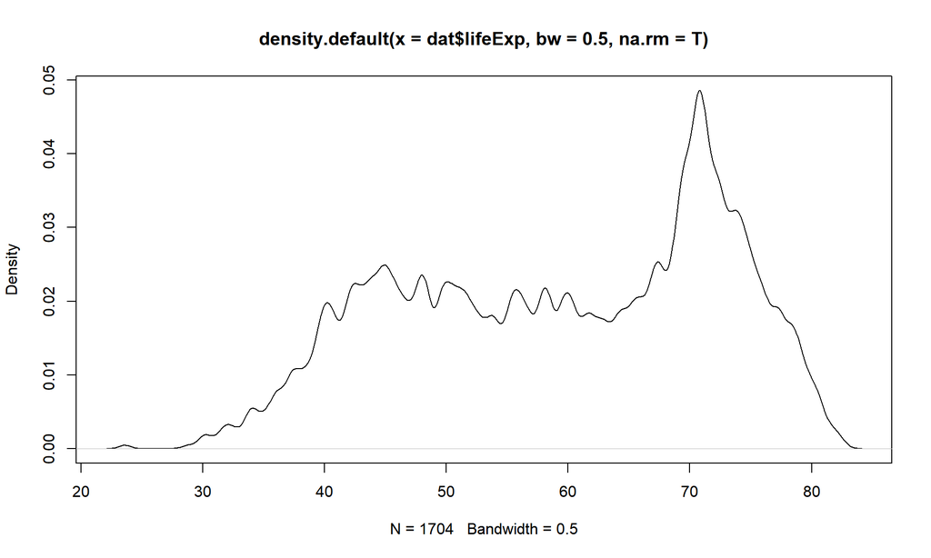

```r
# Plot the density object, bandwidth of 0.5
plot(x=density(x=dat$lifeExp, bw=.5, na.rm=T))
```

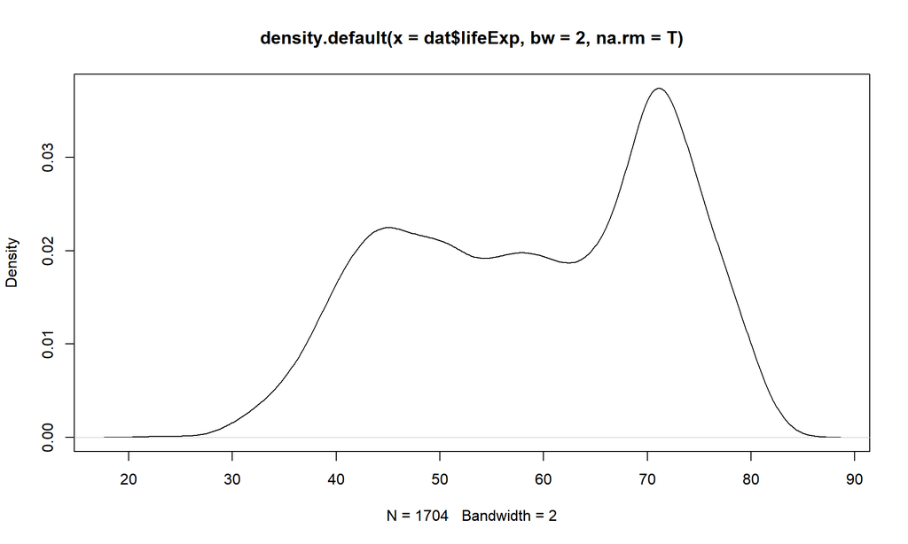

```r
# Plot the density object, bandwidth of 2
plot(x=density(x=dat$lifeExp, bw=2, na.rm=T))
```

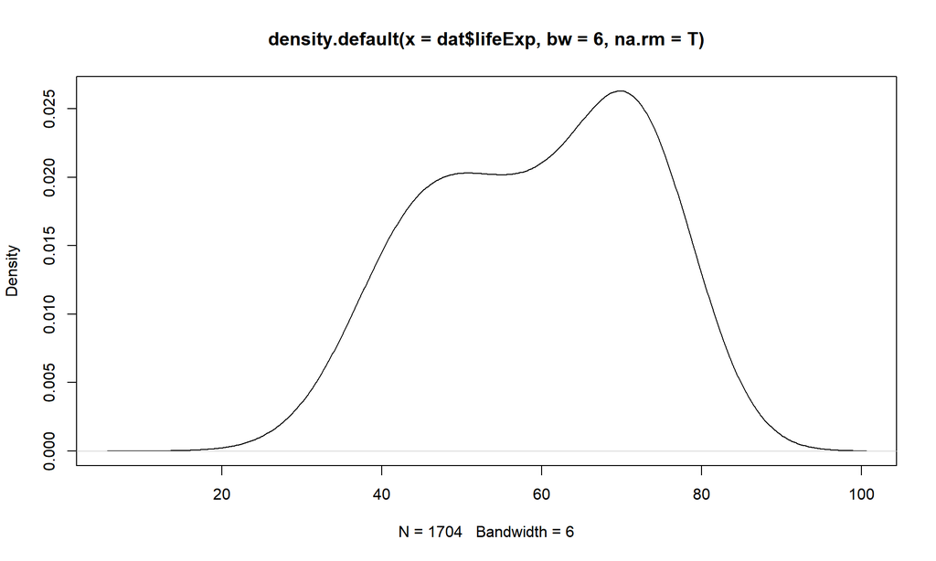

```r
# Plot the density object, bandwidth of 6
plot(x=density(x=dat$lifeExp, bw=6, na.rm=T))
```

### 1c. Labels

- Basic call with popular labeling arguments

```r
plot(x=, y=, type="", xlab="", ylab="", main="")
```

- From the previous example

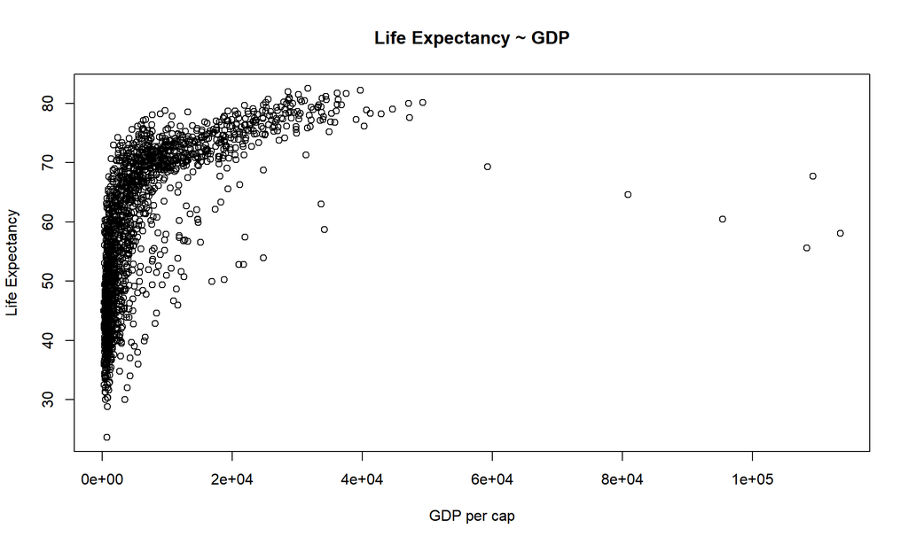

```r
plot(x = dat$gdpPercap, y = dat$lifeExp, type="p", xlab="GDP per cap", ylab="Life Expectancy", main="Life Expectancy ~ GDP") # Add labels for axes and overall plot
```

### 1d. Axis and size scaling

Currently it’s hard to see the relationship between the points due to some strong outliers in GDP per capita. We can change the scale of units on the x axis using scaling arguments.

- Basic call with popular scaling arguments

```r
plot(x=, y=, type="", xlim=, ylim=, cex=)
```

- From the previous example

```r
# Create a basic plot
plot(x = dat$gdpPercap, y = dat$lifeExp, type="p")
```

[output not shown]

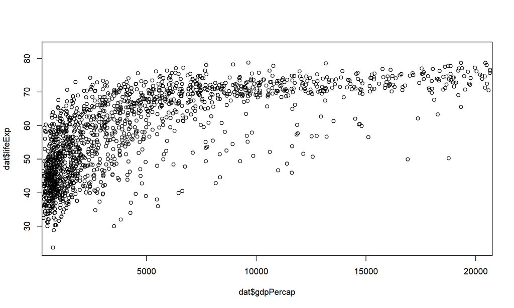

```r
# Limit gdp (x-axis) to between 1,000 and 20,000
plot(x = dat$gdpPercap, y = dat$lifeExp, xlim = c(1000,20000))
```

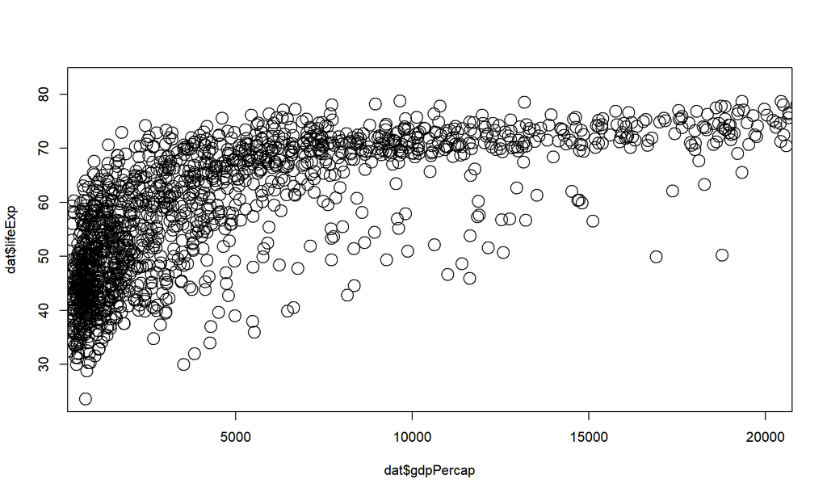

```r
# Limit gdp (x-axis) to between 1,000 and 20,000, increase point size to 2
plot(x = dat$gdpPercap, y = dat$lifeExp, xlim = c(1000,20000), cex=2)
```

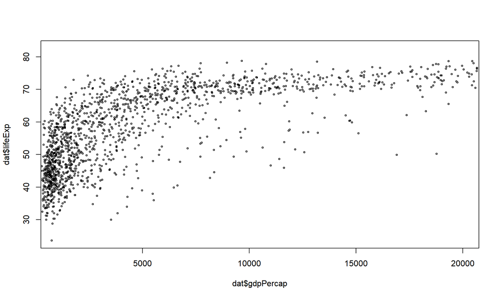

```r
# Limit gdp (x-axis) to between 1,000 and 20,000, decrease point size to 0.5
plot(x = dat$gdpPercap, y = dat$lifeExp, xlim = c(1000,20000), cex=0.5)
```

### 1e. Graphical parameters

- Basic call with popular scaling arguments

```r
plot(x=, y=, type="", col="", pch=, lty=, lwd=)
```

- Colors

```r
colors() # View all elements of the color vector
```

```
##   [1] "white"                "aliceblue"            "antiquewhite"
##   [4] "antiquewhite1"        "antiquewhite2"        "antiquewhite3"
##   [7] "antiquewhite4"        "aquamarine"           "aquamarine1"
##  [10] "aquamarine2"          "aquamarine3"          "aquamarine4"
##  [13] "azure"                "azure1"               "azure2"
##  [16] "azure3"               "azure4"               "beige"
##  [19] "bisque"               "bisque1"              "bisque2"
##  [22] "bisque3"              "bisque4"              "black"
##  [25] "blanchedalmond"       "blue"                 "blue1"
##  [28] "blue2"                "blue3"                "blue4"
##  [31] "blueviolet"           "brown"                "brown1"
##  [34] "brown2"               "brown3"               "brown4"
##  [37] "burlywood"            "burlywood1"           "burlywood2"
##  [40] "burlywood3"           "burlywood4"           "cadetblue"
##  [43] "cadetblue1"           "cadetblue2"           "cadetblue3"
```

[output cut: 204 more lines]

```r
colors()[179] # View specific element of the color vector
```

```
## [1] "gray26"
```

Another option: [R Color Infographic](http://research.stowers-institute.org/efg/R/Color/Chart/ColorsChart1.jpg)

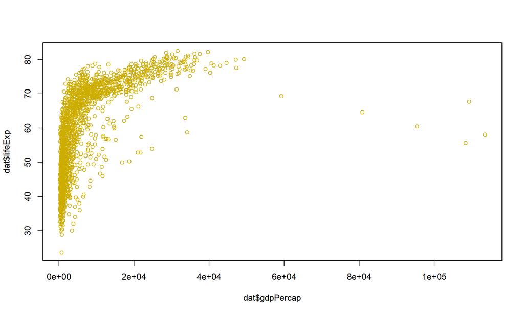

```r
plot(x = dat$gdpPercap, y = dat$lifeExp, type="p", col=colors()[145]) # or col="gold3"
```

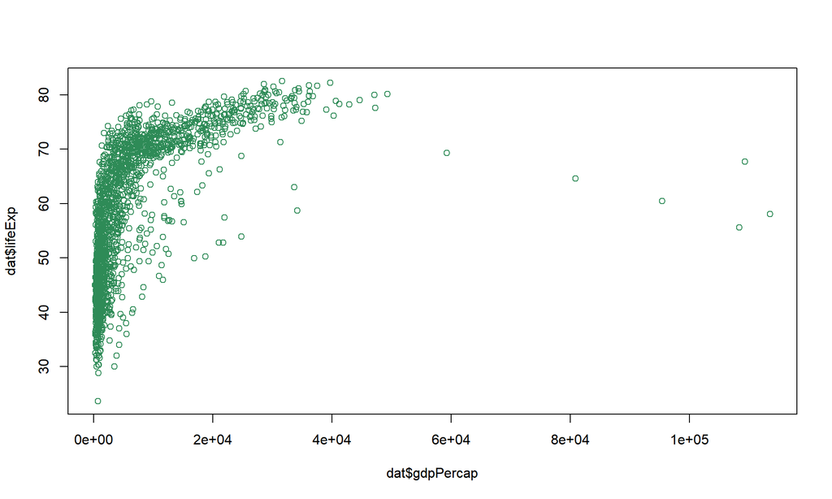

```r
plot(x = dat$gdpPercap, y = dat$lifeExp, type="p", col="seagreen4") # or col=colors()[578]
```

- Point Styles and Widths

[A Good Reference](http://www.endmemo.com/program/R/pic/pchsymbols.png)

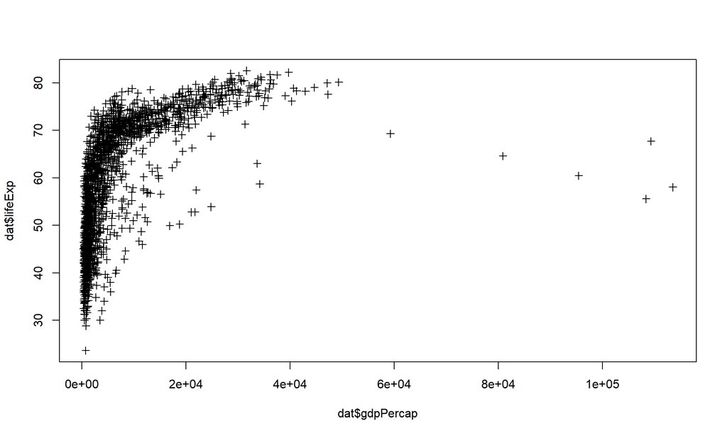

```r
# Change point style to crosses
plot(x = dat$gdpPercap, y = dat$lifeExp, type="p", pch=3)
```

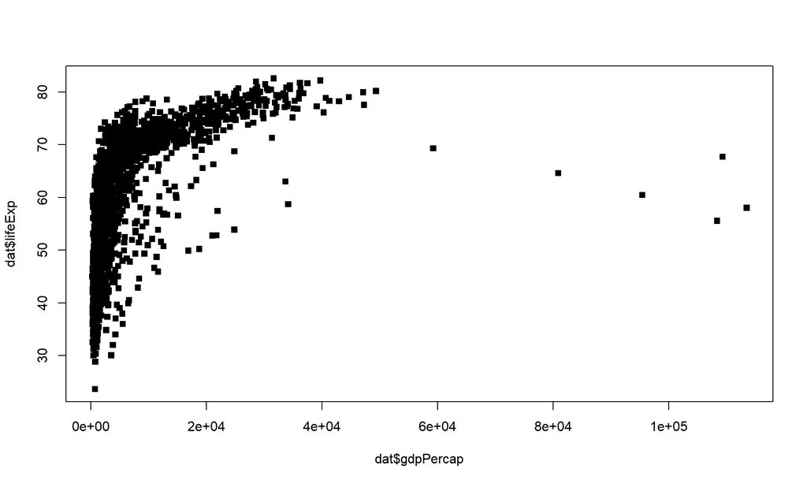

```r
# Change point style to filled squares
plot(x = dat$gdpPercap, y = dat$lifeExp, type="p",pch=15)
```

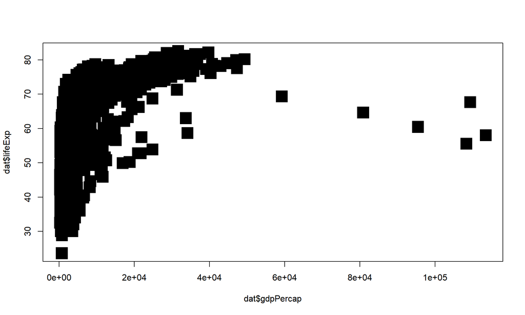

```r
# Change point style to filled squares and increase point size to 3
plot(x = dat$gdpPercap, y = dat$lifeExp, type="p",pch=15, cex=3)
```

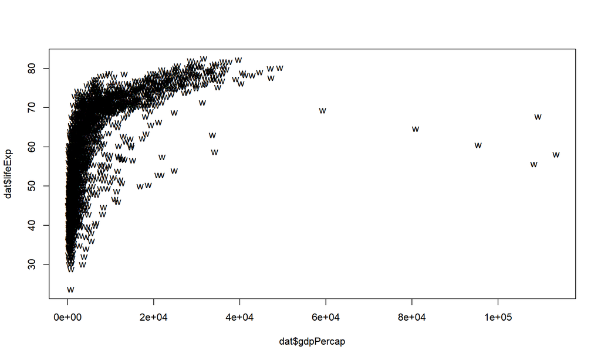

```r
# Change point style to "w"
plot(x = dat$gdpPercap, y = dat$lifeExp, type="p", pch="w")
```

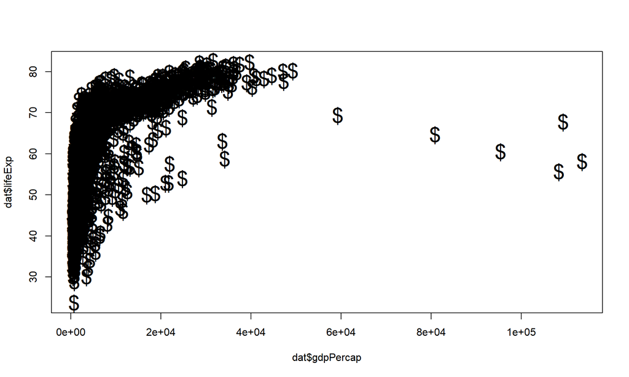

```r
# Change point style to "$" and increase point size to 2
plot(x = dat$gdpPercap, y = dat$lifeExp, type="p",pch="$", cex=2)
```

- Line Styles and Widths

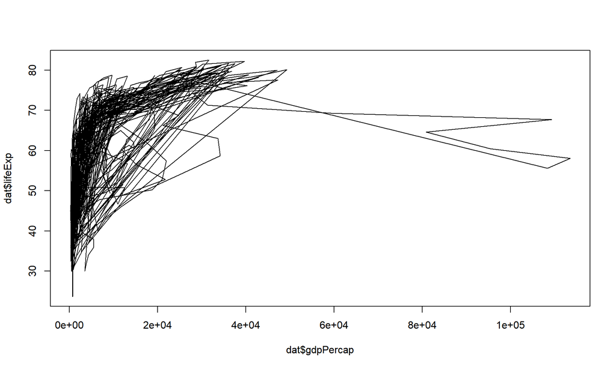

```r
# Line plot with solid line
plot(x = dat$gdpPercap, y = dat$lifeExp, type="l", lty=1)
```

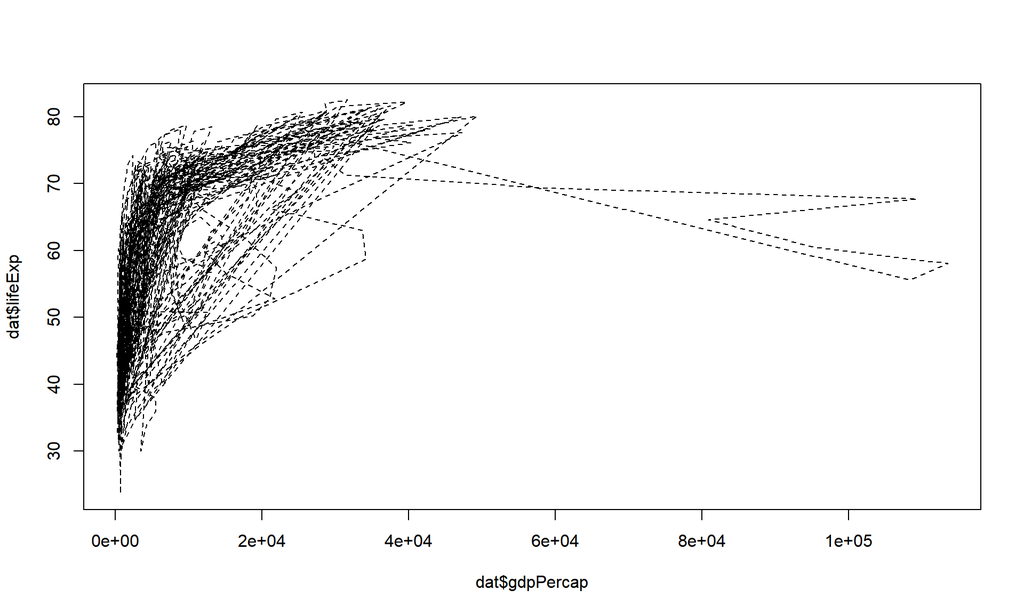

```r
# Line plot with medium dashed line
plot(x = dat$gdpPercap, y = dat$lifeExp, type="l", lty=2)
```

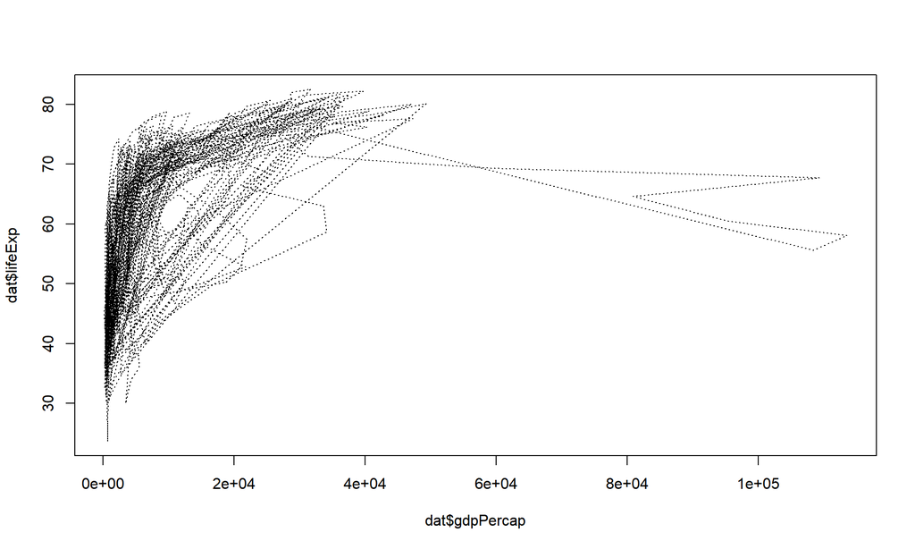

```r
# Line plot with short dashed line
plot(x = dat$gdpPercap, y = dat$lifeExp, type="l", lty=3)
```

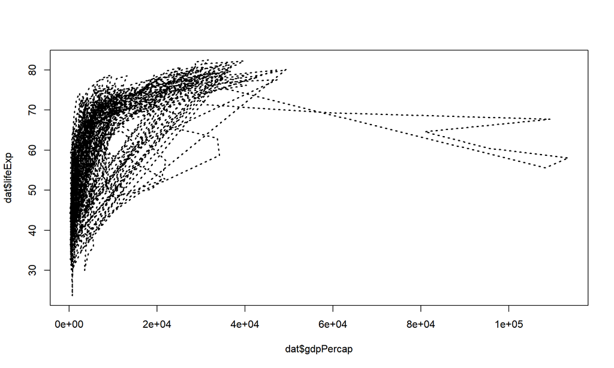

```r
# Change line width to 2
plot(x = dat$gdpPercap, y = dat$lifeExp, type="l", lty=3, lwd=2)
```

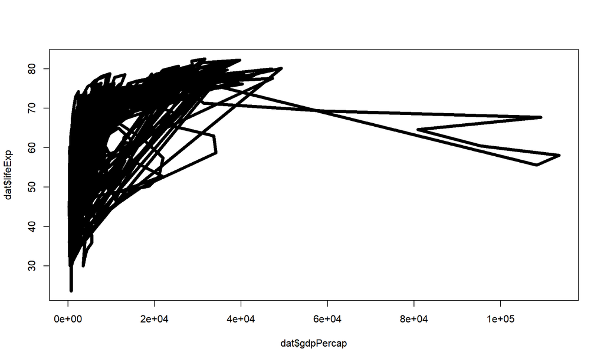

```r
# Change line width to 5
plot(x = dat$gdpPercap, y = dat$lifeExp, type="l",  lwd=5)
```

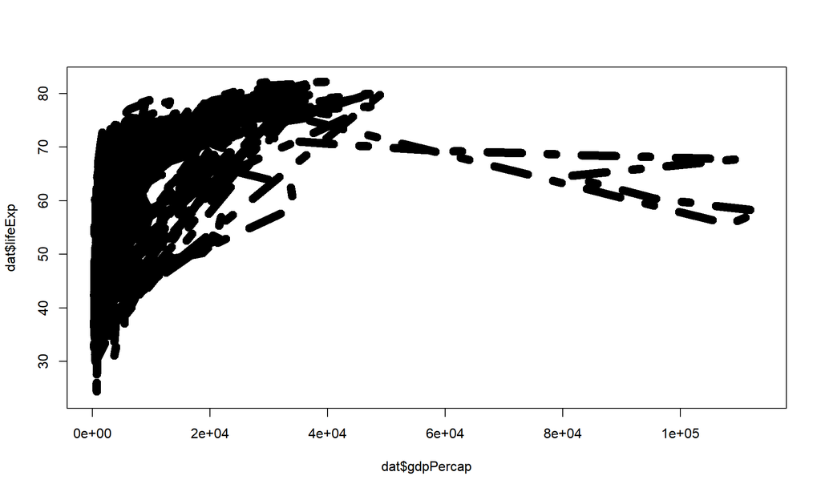

```r
# Change line width to 10 and use dash-dot
plot(x = dat$gdpPercap, y = dat$lifeExp, type="l",  lty=4, lwd=10)
```

### 1f. Annotations, reference lines, and legends

- Text

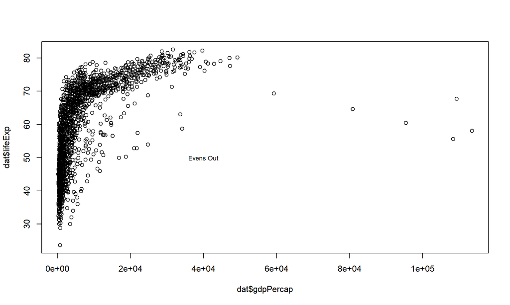

```r
# plot the line first
plot(x = dat$gdpPercap, y = dat$lifeExp, type="p")
# now add the label
text(x=40000, y=50, labels="Evens Out", cex = .75)
```

- Reference Lines

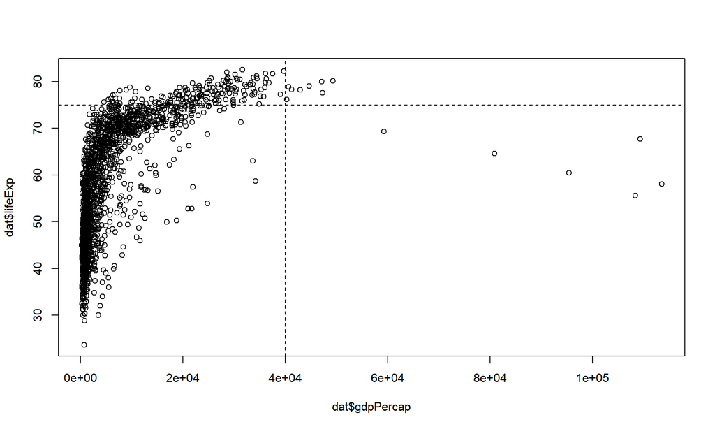

```r
# plot the line
plot(x = dat$gdpPercap, y = dat$lifeExp, type="p")
# now the guides
abline(v=40000, h=75, lty=2)
```

So, plot gets us the basics–but it’s VERY basic. As we said above, it’s usually not much use except as a very rough sketch of our data, like we might want to generate during exploratory data analysis. For more than the basics, we need ggplot.

## 2) Exporting

Two basic image types

### 2.1. **Raster/Bitmap** (.png, .jpeg)

Every pixel of a plot contains its own separate coding; not so great if you want to resize the image. In other words, if you expect to do resizing, or the chart might be displayed at a very different size than what you see on your screen (e.g., a conference presentation), you probably don’t want these formats.

Basic syntax:

```r
jpeg(filename="[ADD FILE PATH & NAME]", width=, height=)
plot(x,y)
dev.off()
```

Example:

```r
jpeg(filename="../03_plots/baser_example1.png")
  # plot the line
  plot(x = dat$gdpPercap, y = dat$lifeExp, type="p")
  # now the guides
  abline(v=40000, h=75, lty=2)
dev.off()
```

### 2.2. **Vector** (.pdf, .ps)

Every element of a plot is encoded with a function that gives its coding conditional on several factors; great for resizing (presentations, etc.).

Basic syntax:

```r
pdf(filename="[ADD FILE PATH & NAME]", width=, height=)
plot(x,y)
dev.off()
```

Example:

```r
pdf("../03_plots/baser_plots.pdf")
  # plot the line
  plot(x = dat$gdpPercap, y = dat$lifeExp, type="p")
  # now the guides
  abline(v=40000, h=75, lty=2)
dev.off()
```